# Assignment-4

2024-02-13

```r
library(readr)
library(dplyr)
library(Amelia)
library(factoextra)
library(cluster)
library(caret)
```

### Part I: Implementing a Simple Prediction Pipeline

1. Perform basic data cleaning.

```r
# path where datasets are stored as working directory
setwd("/Users/apple/Desktop/8451 Machine Learning for Epi/Assignment-4")

# read dataset
data <- read_csv("./class4_p1.csv")

# rename the variable names to make them more easy to understand
var.names <- c("id","hypertension","diabetes","asthma","bmi","tobacco","alcohol","physical_activity_total_minutes","physical_activity_days","physically_active","diet","agegroup","sex","hispanic","born_in_us","poverty_group","healthy_days")

colnames(data) <- var.names

# check which features are continuous and which are categorical
data |> str()
```

```
## spc_tbl_ [3,811 × 17] (S3: spec_tbl_df/tbl_df/tbl/data.frame)
##  $ id                             : num [1:3811] 1 2 3 4 5 6 7 8 9 10 ...
##  $ hypertension                   : num [1:3811] 2 2 1 2 2 1 1 1 1 2 ...
##  $ diabetes                       : num [1:3811] 2 2 1 2 2 1 1 1 1 2 ...
##  $ asthma                         : num [1:3811] 2 2 2 1 2 2 2 2 2 2 ...
##  $ bmi                            : num [1:3811] 26.8 28.2 39.2 42.5 22.3 ...
##  $ tobacco                        : num [1:3811] 3 3 1 3 3 3 3 3 3 2 ...
##  $ alcohol                        : num [1:3811] 3 3 2 3 NA 2 2 3 2 2 ...
##  $ physical_activity_total_minutes: num [1:3811] 0 120 60 180 0 0 0 0 15 0 ...
##  $ physical_activity_days         : num [1:3811] 5 5 3 5 7 7 7 5 5 7 ...
##  $ physically_active              : num [1:3811] 3 1 1 2 2 3 2 3 4 2 ...
##  $ diet                           : num [1:3811] NA NA NA NA NA NA NA NA NA NA ...
##  $ agegroup                       : num [1:3811] 1 3 3 2 2 3 3 4 3 2 ...
##  $ sex                            : num [1:3811] 2 2 1 2 2 1 1 1 2 1 ...
##  $ hispanic                       : num [1:3811] 1 2 1 1 2 2 1 1 1 1 ...
##  $ born_in_us                     : num [1:3811] 2 2 1 2 2 1 2 2 1 1 ...
##  $ poverty_group                  : num [1:3811] 1 3 6 2 6 3 4 6 3 1 ...
##  $ healthy_days                   : num [1:3811] 24 30 NA 23 30 30 30 10 0 30 ...
##  - attr(*, "spec")=
##   .. cols(
##   ..   ...1 = col_double(),
##   ..   chronic1 = col_double(),
##   ..   chronic3 = col_double(),
##   ..   chronic4 = col_double(),
##   ..   bmi = col_double(),
##   ..   tobacco1 = col_double(),
##   ..   alcohol1 = col_double(),
##   ..   gpaq8totmin = col_double(),
##   ..   gpaq11days = col_double(),
##   ..   habits5 = col_double(),
##   ..   habits7 = col_double(),
##   ..   agegroup = col_double(),
##   ..   dem3 = col_double(),
##   ..   dem4 = col_double(),
##   ..   dem8 = col_double(),
##   ..   povertygroup = col_double(),
##   ..   healthydays = col_double()
##   .. )
##  - attr(*, "problems")=<externalptr>
```

```r
# The results from str() show all the features are numeric. However, all features except for id, bmi, physical_activity_total_minutes, physical_activity_days, and healthy_days need to be categorical.

# convert categorical variables that have been read-in as continous variables
data <- data |> mutate_at(vars(id,hypertension,diabetes,asthma,tobacco,alcohol,
                            physically_active,diet,agegroup,sex,hispanic,born_in_us,
                            poverty_group), as.factor)

# check missing data
data |> missmap(main = "Missing values vs observed")
```

[figure not shown]

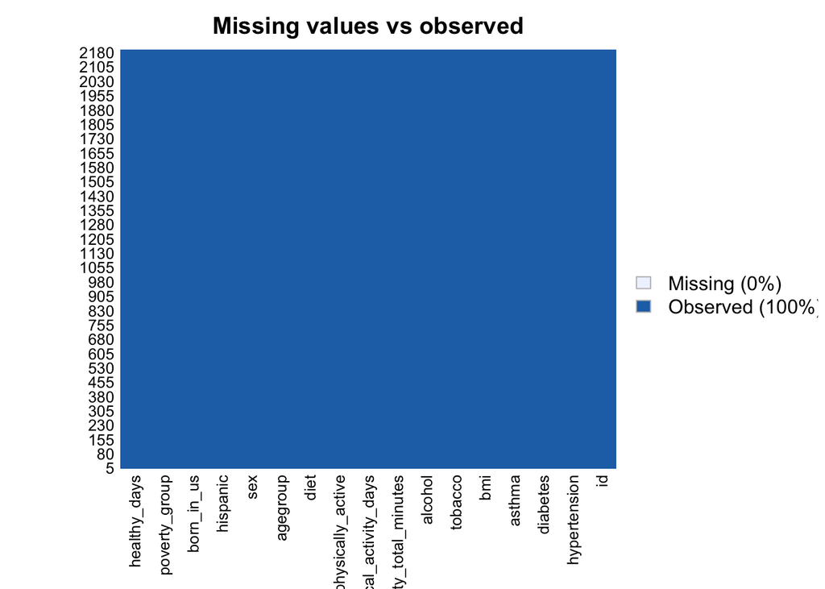

```r
# The missing map shows only 3% of the data are missing. However, we may still want to omit missing value.

# omit missing value
data <- data |> na.omit()

# check missing data age
data |> missmap(main = "Missing values vs observed")
```

```r
# Now, there is no missing value.

# check whether there is only one id per person
data <- data |> distinct(id, .keep_all = TRUE)

# No change of the observation's number indicates there was no duplicate in the dataset.

# remove the id variable
data$id <- NULL
```

2. Partition data into training and testing (use a 70/30 split)

```r
# set seed
set.seed(123)

# split data into training and testing
train.index = createDataPartition(data$healthy_days, p = 0.7, list = FALSE)

train = data[train.index, ]
test = data[-train.index, ]
```

3. Fit two prediction models using different subsets of the features in the training data.

**Discussion:**

- Model 1 : healthy_days ~ hypertension + physical_activity_days
- Model 2 : healthy_days ~ hypertension + diabetes + asthma + tobacco + alcohol + physically_active + diet + agegroup + sex + hispanic + born_in_us + poverty_group

```r
# Avoid overfitting by repeated cross-validation
control = trainControl(method="repeatedcv", number=10, repeats=10, summaryFunction=defaultSummary)

# fit prediction models
model1 = train(healthy_days ~ hypertension + physical_activity_days, data = train, method = "lm", trControl = control)
model2 = train(healthy_days ~ hypertension + diabetes + asthma + tobacco +
                       alcohol + physically_active + diet + agegroup + sex +
                       hispanic + born_in_us + poverty_group, data = train, method = "lm", trControl = control)
```

4. Apply both models within the test data and determine which model is the preferred prediction model using the appropriate evaluation metric(s).

```r
# make predictions within test dataset
prediction1 = predict(model1, test)
prediction2 = predict(model2, test)

# evaluate the models using mean squared error
mse1 = mean((prediction1 - test$healthy_days)**2/nrow(test)) |> print()
```

```
## [1] 0.08535169
```

```r
mse2 = mean((prediction2 - test$healthy_days)**2/nrow(test)) |> print()
```

```
## [1] 0.07830613
```

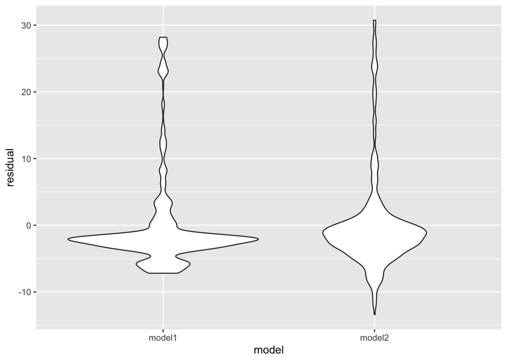

```r
model1_result = bind_rows(train = prediction1, test = test$healthy_days, .id = "split")
model2_result = bind_rows(train = prediction2, test = test$healthy_days, .id = "split")
result = bind_rows(model1 = model1_result, model2 = model2_result, .id = "model")

# calculate the residual
result = result |>
  mutate(residual = train - test)

# plot the residual
result |>
  ggplot(aes(x = model, y = residual)) + geom_violin()
```

5. Describe one setting where the implementation of your final model would be useful.

**Discussion:** The Model 2 is capable of predicting the number of days an individual reports having good physical health in a month. This prediction is derived from a comprehensive evaluation of medical conditions, lifestyle habits, and sociodemographic factors. The insights gleaned from this model can inform targeted health interventions and resource allocation strategies aimed at enhancing the overall well-being of the population in New York City.

### Part II: Conducting an Unsupervised Analysis

Using the dataset from the Group assignment Part 3 (USArrests), identify clusters using hierarchical analysis.

6. Conduct a hierarchical clustering analysis. Use a Euclidian distance measure to construct your dissimilarity matrix. Use complete linkage.

```r
# import dataset
data("USArrests")

# strip off the outcome and id variable
USArrests <- USArrests |> select("Murder", "Assault", "UrbanPop", "Rape")

# determine if scale is necessary
USArrests |> summarise_all(mean, na.rm = TRUE) |>
  print()
```

```
##   Murder Assault UrbanPop   Rape
## 1  7.788  170.76    65.54 21.232
```

```r
USArrests |> summarise_all(sd, na.rm = TRUE) |>
  print()
```

```
##    Murder  Assault UrbanPop     Rape
## 1 4.35551 83.33766 14.47476 9.366385
```

```r
# Since the mean and standard deviation's magnitude are different for each variable. So, we decide to center and scale.

# set seed
set.seed(123)

# center and scale
set.up.preprocess = preProcess(USArrests, method = c("center", "scale"))

# output pre-processed values
transformed.vals = predict(set.up.preprocess, USArrests)

# compare the sds used to scale to the sds above to ensure they are close
USArrests$scale
```

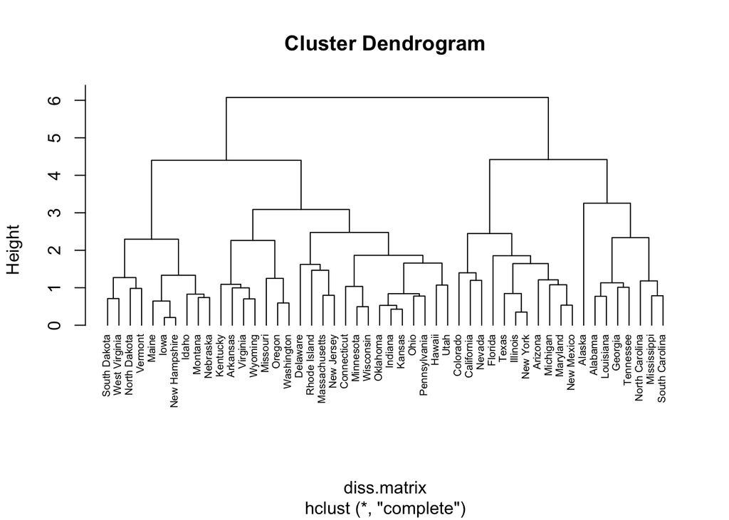

```r
# The sds used to scale to the sds above are close.

# conduct clustering analysis using hierarchical clustering by creating dissimilarity matrix first
diss.matrix <- dist(transformed.vals, method = "euclidean")

# hierarchical clustering using complete linkage
clusters.hcut <- hclust(diss.matrix, method = "complete")

# plot the obtained dendrogram
plot(clusters.hcut, cex = 0.6, hang = -1)
```

[output not shown]

7. Determine the optimal number of clusters using a clear, data-driven strategy.
- We could determine the optimal number of cluster by looking at the Gap Statistic Graph. Since when number of clusters k = 4, it gives us the highest Gap Statistic. Therefore, the optimal number of clusters is 4.

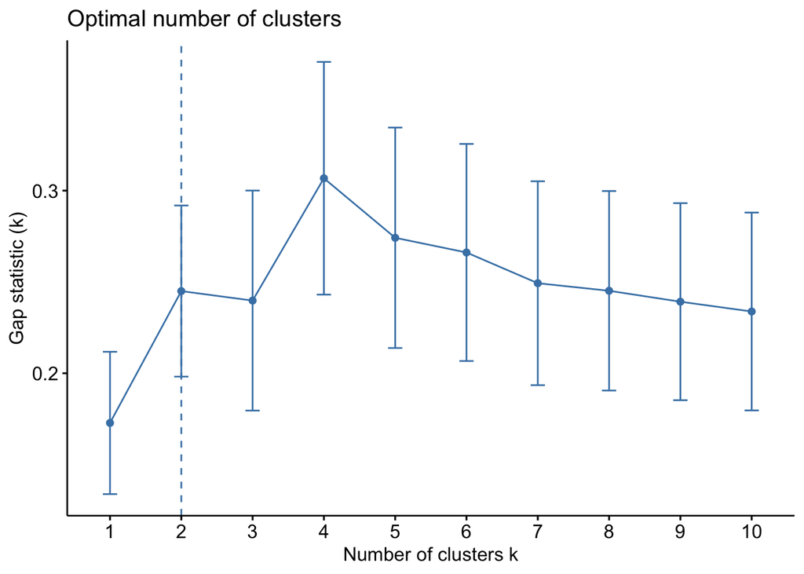

```r
# use complete method
gap_stat = clusGap(transformed.vals, FUN = hcut, hc_method="complete", K.max = 10, B = 50)
fviz_gap_stat(gap_stat)
```

```r
# use number of clusters from gap statistic to obtain cluster assignment for each observation
clusters.h.4 <- cutree(clusters.hcut, k=4)
table(clusters.h.4)
```

```
## clusters.h.4
##  1  2  3  4
##  8 11 21 10
```

```r
# set k to be 4
clusters.hcut=hcut(transformed.vals, k=4, hc_func="hclust", hc_method="complete", hc_metric="euclidian")
```

8. Describe the composition of each cluster in terms of the original input features

**Discussion:**

```r
# show the mean value of features within each cluster
# bind the cluster value to original data
input.feature.vals=cbind(transformed.vals,cluster=clusters.hcut$cluster)

# summarize the mean value of features within each cluster
input.feature.vals |> group_by(cluster) |>
  summarise_all(mean)
```

```
## # A tibble: 4 × 5
##   cluster Murder Assault UrbanPop   Rape
##     <int>  <dbl>   <dbl>    <dbl>  <dbl>
## 1       1  1.45    0.984   -0.832  0.353
## 2       2  0.750   1.12     0.936  1.22
## 3       3 -0.440  -0.435    0.361 -0.283
## 4       4 -1.06   -1.10    -1.12  -1.03
```

```r
# check size of the clusters
clusters.hcut$size
```

```
## [1]  8 11 21 10
```

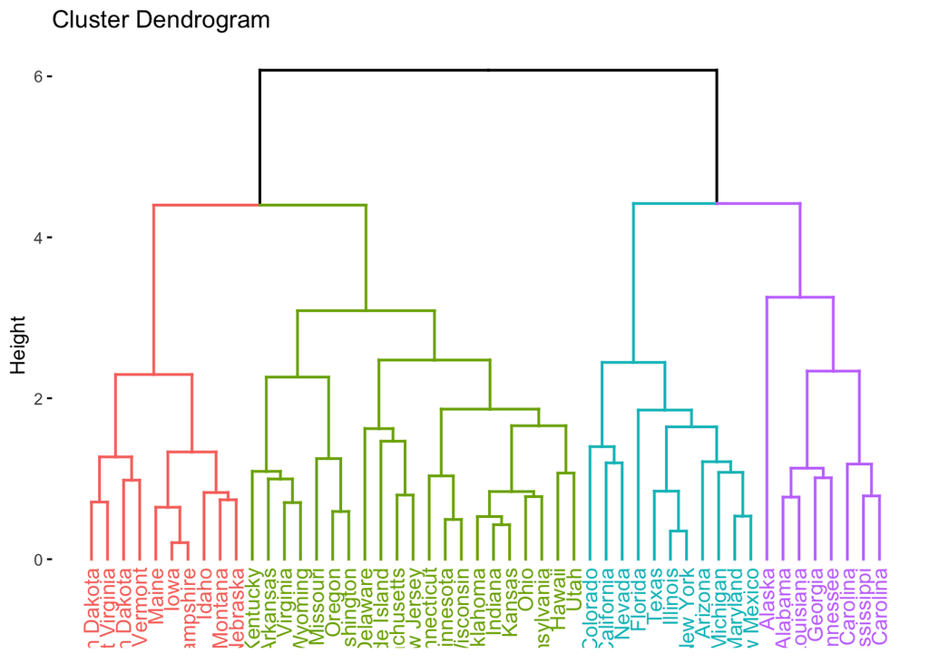

```r
# check cluster dendrogram
fviz_dend(clusters.hcut)
```

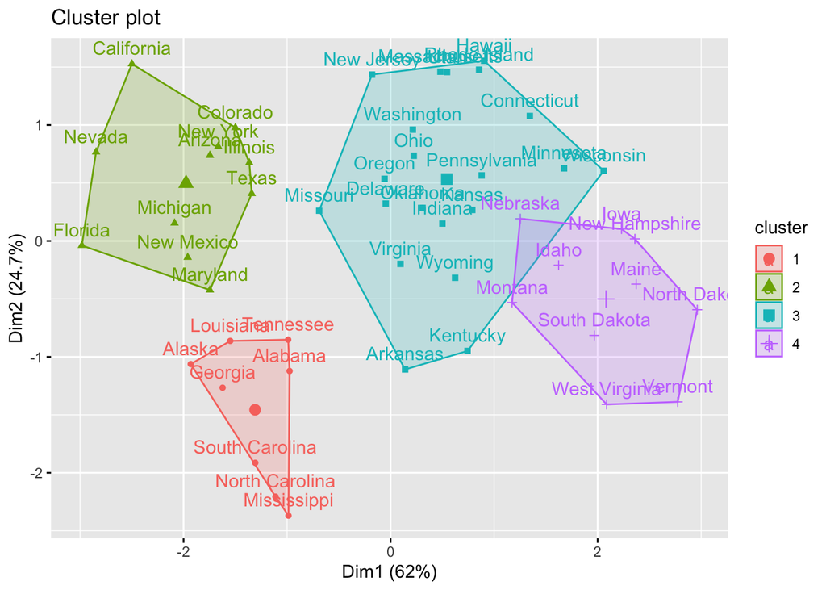

```r
# check cluster plot
fviz_cluster(clusters.hcut)
```

9. Pretend that the data are from 2022 and not 1973. Describe one research question that can be addressed using the newly identified clusters. Briefly comment on any scientific or ethical considerations one should review before using these clusters for your specific question.

**Discussion:**

- We can investigate if the relationship between the outcome urban population size and indicators for crime such as murder, assault, and rape rate varies by clusters. If the data are from 2022, there might be more features available such as sociodemographic data as well. So, in terms of scientific considerations, we need to consider which feature we should select and how many clusters there need to have. In terms of ethical considerations, we should check whether the data is representative for all sociodemographic groups in the society to avoid a biased dataset where certain groups are neglected.
10. Optional Repeat analysis with a different linkage method (e.g. single or average). Do the clusters change?

```r
# change the linkage method to single
clusters.hcut.4 <-hcut(USArrests, k = 4, hc_func = "hclust", hc_method = "single", hc_metric = "euclidian")

# check size of the clusters
clusters.hcut.4$size
```

```
## [1] 47  1  1  1
```

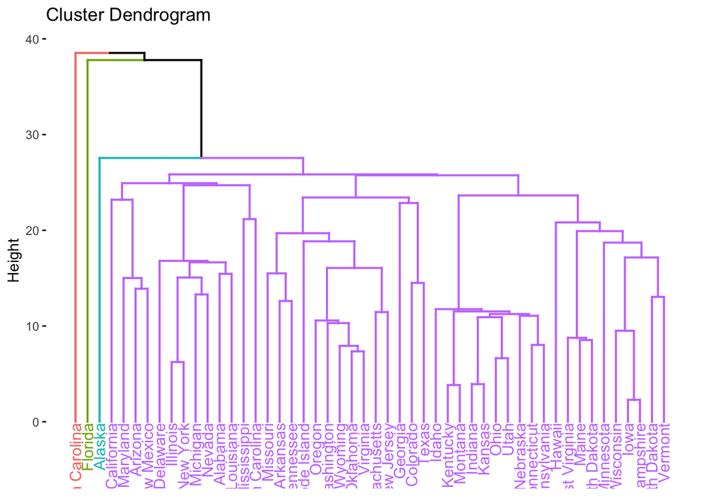

```r
# check cluster dendrogram
fviz_dend(clusters.hcut.4)
```

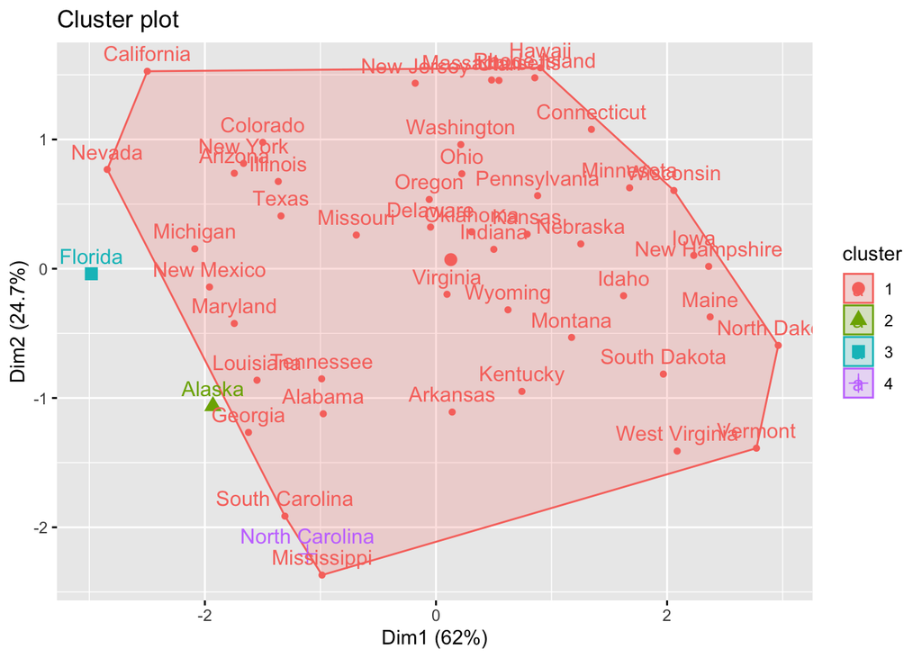

```r
# check cluster plot
fviz_cluster(clusters.hcut.4)
```

```r
# bind the cluster value to original data
input.feature.vals <-cbind(transformed.vals,cluster = clusters.hcut.4$cluster)

# summarize the mean value of features within each cluster
input.feature.vals |> group_by(cluster) |>
  summarise_all(mean)
```

```
## # A tibble: 4 × 5
##   cluster  Murder Assault UrbanPop    Rape
##     <int>   <dbl>   <dbl>    <dbl>   <dbl>
## 1       1 -0.0735  -0.108   0.0347 -0.0654
## 2       2  0.508    1.11   -1.21    2.48
## 3       3  1.75     1.97    0.999   1.14
## 4       4  1.20     1.99   -1.42   -0.548
```

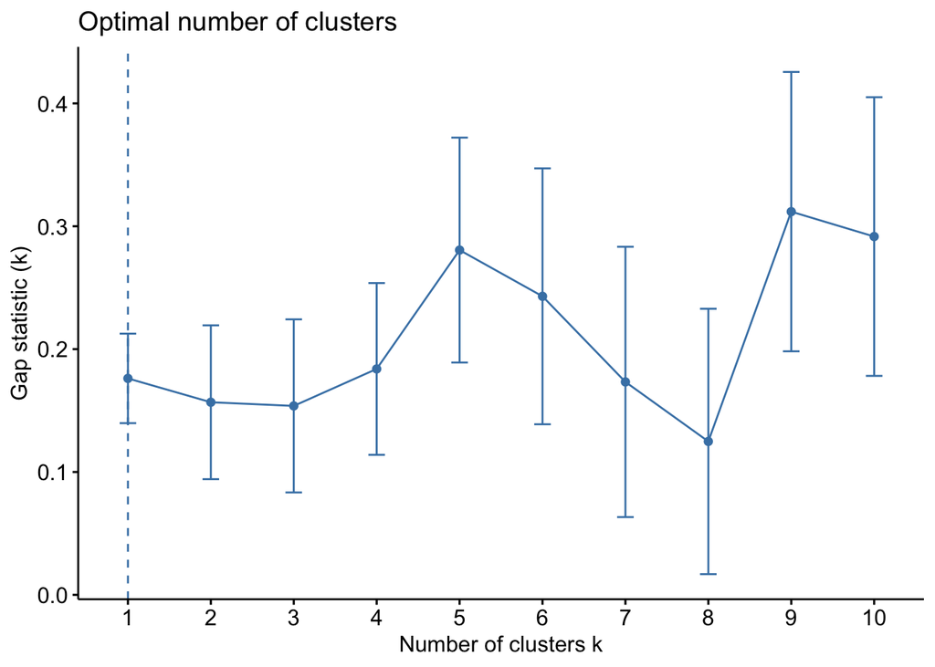

```r
# Since 4 clusters may not delineate distinct patterns, we want to search for the best number of clusters.
gap_stat <- clusGap(transformed.vals, FUN = hcut, hc_method="single", K.max = 10, B = 50)
fviz_gap_stat(gap_stat)
```

```r
# 9 has the highest Gap Statistics

# repeat the previous code for 9 clusters
clusters.hcut.9 <-hcut(USArrests, k = 9, hc_func = "hclust", hc_method = "single", hc_metric = "euclidian")

# check size of the clusters
clusters.hcut.9$size
```

```
## [1]  7  1  4 14 10  1 10  2  1
```

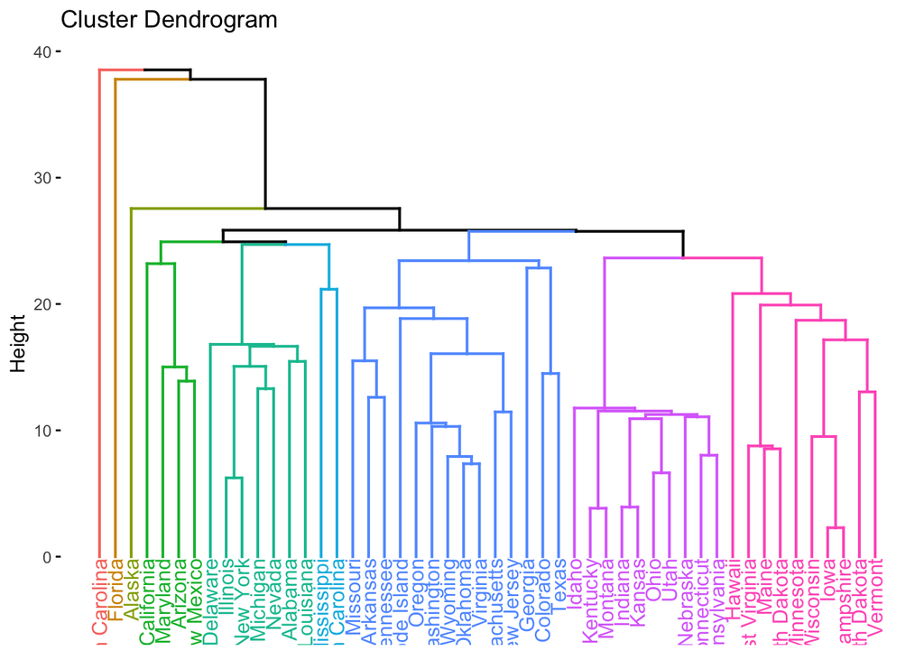

```r
# check cluster dendrogram
fviz_dend(clusters.hcut.9)
```

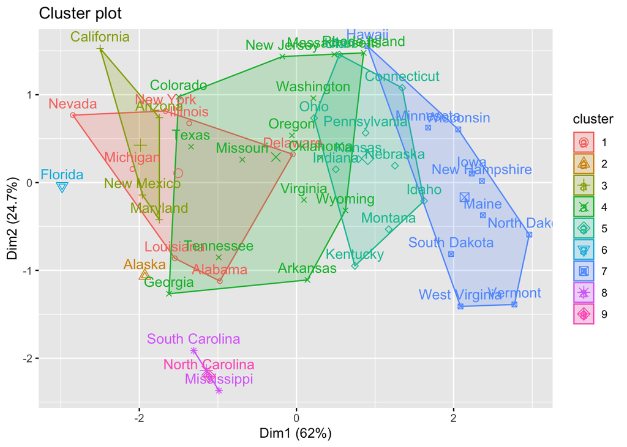

```r
# check cluster plot
fviz_cluster(clusters.hcut.9)
```

```r
# bind the cluster value to original data
input.feature.vals <-cbind(transformed.vals,cluster = clusters.hcut.9$cluster)

# summarize the mean value of features within each cluster
input.feature.vals |> group_by(cluster) |>
  summarise_all(mean)
```

```
## # A tibble: 9 × 5
##   cluster  Murder Assault UrbanPop   Rape
##     <int>   <dbl>   <dbl>    <dbl>  <dbl>
## 1       1  0.846   0.922   0.604    0.637
## 2       2  0.508   1.11   -1.21     2.48
## 3       3  0.496   1.42    0.792    1.24
## 4       4  0.0979  0.0303  0.353    0.172
## 5       5 -0.505  -0.700   0.00415 -0.423
## 6       6  1.75    1.97    0.999    1.14
## 7       7 -1.11   -1.30   -0.804   -1.04
## 8       8  1.71    1.18   -1.35    -0.153
## 9       9  1.20    1.99   -1.42    -0.548
```

**Discussion:**

The clusters change after using a different linkage method, specifically the single linkage method. With the complete linkage method, specifying a desire for 4 clusters results in clusters of relatively similar size, comprising 8, 11, 21, and 10 states, respectively. Conversely, when employing the single linkage method, one cluster emerges significantly larger, encompassing 47 states, while the remaining three clusters contain only one state each. Moreover, the cluster dendrograms exhibit disparity, illustrating that while the complete linkage method yields clusters of comparable size, the single linkage method tends to aggregate most states into a single cluster, as we can see in lower branches. The single linkage method produces a sizable cluster characterized by moderate values across all four features, namely murder rate, assault rate, rape rate, and urban population size. However, compared to the complete linkage method, the single linkage method does not effectively delineate distinct clusters when aiming to create 4 clusters. After adjusting the number of clusters to 9, which is deemed optimal according to the single linkage method, we observed considerable disparities in the sizes of the resulting clusters (7, 1, 4, 14, 10, 1, 10, 2, 1). Furthermore, the cluster plot revealed overlaps in the areas associated with each cluster. Consequently, our analysis suggests that, overall, the complete linkage method may perform better than the single linkage method in this scenario.